# Visualizing Predictions

Author

Kris Sankaran

Published

September 1, 2026

[Reading](https://ema.drwhy.ai/partialDependenceProfiles.html) Code

1. When we read data analysis reports or attend statistical research seminar, we are bound to be bombarded by numerical outputs from models, $p$-values, test set accuracies, parameter estimates, $R^2$ values… This is all helpful for keeping everyone honest about how good models really are, but if we want to build intuition (and improve) models, then it really helps to visualize them.
2. In fact, we can integrate visualization throughout the model building process. In data science, there is a cliche that visualization is mainly useful at the very beginning (exploratory data analysis) or end (pretty presentations) of a study. But careful modeling requires visualization at all steps.
3. UW-Madison’s Statistics Department was founded by George Box, one of the most important statisticians of the 20th century. Among many methdological contributions, he is famous for the quote, “All models are wrong, but some are useful.” I’ve always found it a bit unfortunate that this quote became so popular without the related idea, “Box’s Loop,” becoming similarly famous. The idea of the Loop is that we should seek out limitations in our models (“all models are wrong”) but then use that to suggest improvements.

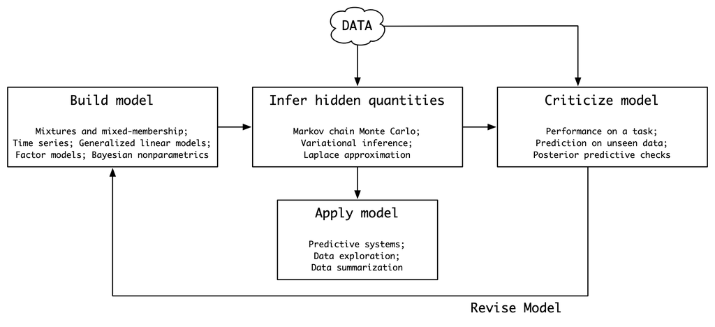

4. If this seems a little abstract, consider this example from the reading. The 538 blog releases election forecasts based on statistical models trained on polling and historical election data. We’ll consider a model they built just before the 2020 US Presidential Election between Joe Biden and Donald Trump. This supports simulation, so we can generate hypothetical election results using the fitted model parameters. For each of the simulated datasets, we get a percentage breakdown Biden vs. Trump for each state.
5. If we average the statewise results across all the simulated elections, then the model makes sense, considering voting patterns in recent elections. For example, California reliably votes for the Democrat (Biden) while Wyoming reliably votes for the Republican (Trump).

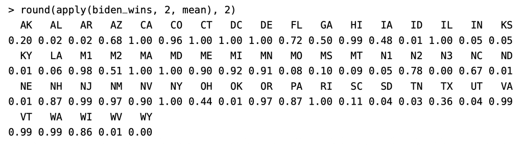

6. Further, for particular pairs of states, the correlations match our expectations. For example, Wisconsin and Pennsylvania are traditionally “swing” states, which have gone to either Democrats or Republicans in recent elections. If we plot the simulated outcomes against one another, then they are positively correlated, which is what we would expect if there were events (in the time between the forecast and the final election) that either improved or damaged their chances consistently across both states.

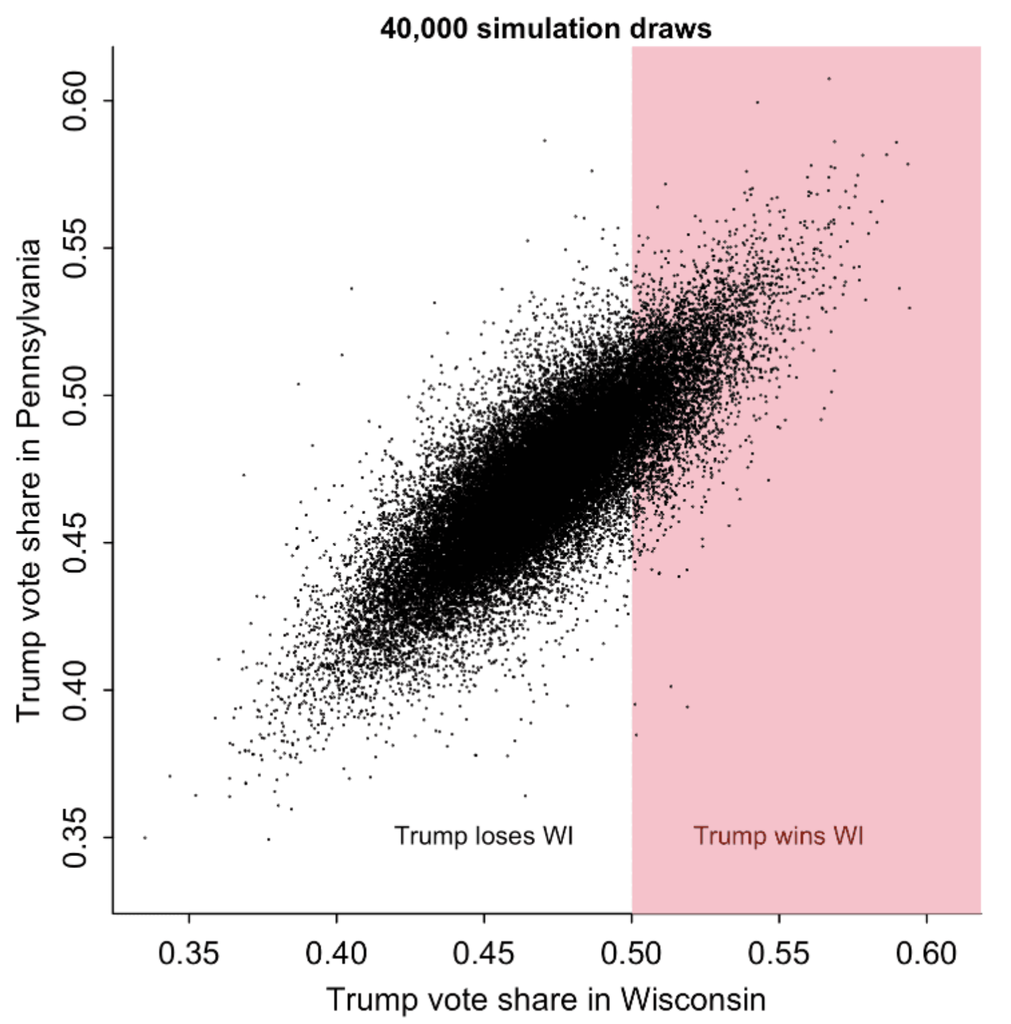

7. But for other pairs, the results are suspicious. For example, the simulations suggest that the outcomes in Washington (a Democrat-leaning state) and Mississippi (a Republican-leaning state) are negative correlated. This is strange, because it means that if Trump won Washington, he would be more likely to *lose* Mississippi. You would think that if he had won a historic upset and succeeded in Washington, then surely he would have also won in Mississippi.

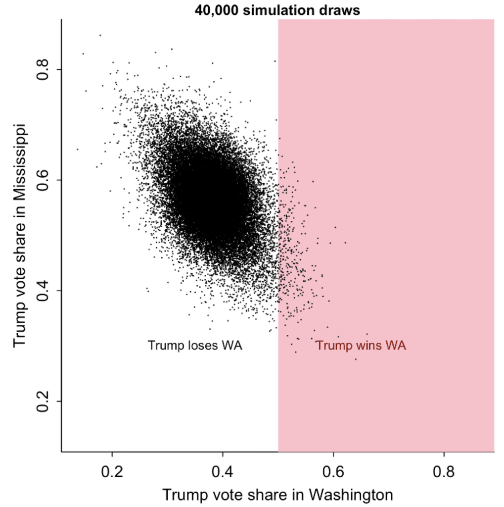

8. The authors of our reading argue that this negative correlation is a technical artifact of teh statistical model used by the 538 team, and not a real pattern from any historical data. It turns out that the default statistical choice the team used is not really compatible with our knowledge about the problem setting. This is a place where defaults could be adapted to obtain a more realistic model; i.e., it motivates moving through an interation of Box’s loop.

## Probabilistic Models

### Notation

9. If the election example feels a bit ad hoc to you, then you have a good instinct for statistics. One of the goals of statistical methods research is to formalize good intuition using more mathematical language, and that’s exactly what we’ll do here. In this way, we’ll ensure that good ideas that appear in one specific field can be easily adapted to other fields.
10. We will use the following notation. A simulation model is one that allows us to draw replicate datasets $y_{i}^{\text{rep}}$ given an observed dataset $y$,
    $$y_{1}^{\text{rep}}, \dots, y_{n}^{\text{rep}} \sim p\left(y^{\text{rep}} \vert y\right).$$
    You should think of each $y_{i}^{\text{rep}}$ and $y$ as vectors, because they represent an entire dataset.
    - In our reading, the probability on the right hand side is called the **posterior predictive distribution**. The hope is that after having observed the real dataset $y$, the distribution $p\left(y^{\text{rep}} \vert y\right)$ should allow us to simulate new replicates that look similar to the real data.
    - In contrast, the **prior predictive distribution**, denoted $p\left(y^{\text{rep}}\right)$, describes how we would simulate new datasets $y^{\text{rep}}$ before having observed any real data $y$.

### Running Example

11. As our running example, we will use a PM2.5 monitoring dataset. PM2.5 is a type of air pollution that can be bad for public health. High-quality weather station data apply in the areas around the weather station, but don’t give any information about what happens in the areas between stations. In contrast, satellite data give global coverage, but they are lower quality. In the last decade, it’s become popular to train models that use high quality station measurements to adjust satellite data, which gets us closer to the best of both worlds. If it works well, it could be used to monitor PM2.5 levels at global scale.

    ```r
    f <- tempfile()
    download.file("https://github.com/jgabry/bayes-vis-paper/blob/master/bayes-vis.RData?raw=true", f)
    GM <- get(load(f))
    GM@data <- GM@data |>
        mutate(
            log_pm25 = log(pm25),
            log_sat = log(sat_2014)
        )
    ```

12. The simplest model simply fits $\text{station} = a + b \times \text{satellite}$ at locations where they are both available. This model was used in practice by the Global Burden of Disease project until 2016.

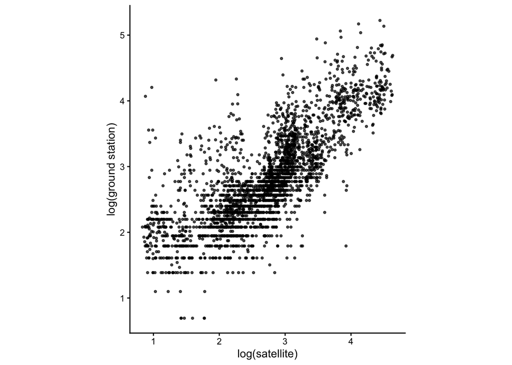

    ```r
    ggplot(GM@data, aes(log_sat, log_pm25)) +
        geom_point(size = 0.8, alpha = 0.7) +
        labs(x = "log(satellite)", y = "log(ground station)", col = "WHO Region") +
        coord_fixed()
    ```

13. When we plot these two variables against one another, we can see that we won’t be able to obtain good predictions for the station measurements using the satellite data alone. What features might we include to improve the model fit?
14. One hypothesis is that country region is an important factor. Below, we fit regression lines separately for different country super-regions, as specified by the WHO. The fact that the slopes are not the same in each region means that we should modify our model to have a different slope in each region 1 .

```r
ggplot(GM@data, aes(log_sat, log_pm25)) +
    geom_point(aes(col = super_region_name), size = 0.4, alpha = 0.7) +
    geom_smooth(aes(col = super_region_name), method = "lm", se = FALSE, size = 2) +
    scale_color_brewer(palette = "Set2") +
    labs(x = "log(satellite)", y = "log(ground station)", col = "WHO Region") +
    coord_fixed()
```

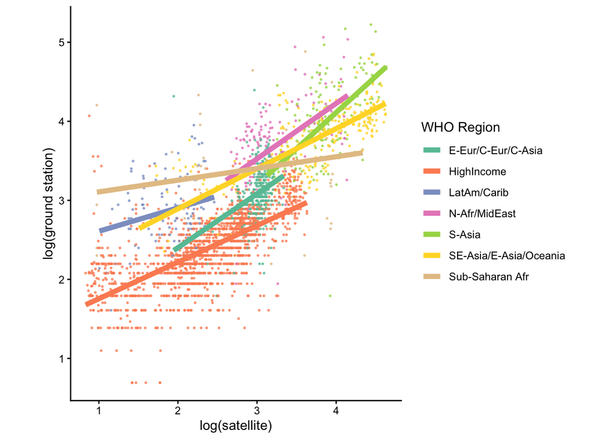

15. The WHO categorizations are somewhat arbitrary. Maybe there are better country groupings, tailored specifically to the PM2.5 problem? One idea is to cluster the ground stations based on PM2.5 level and use these clusters as a different region grouping.

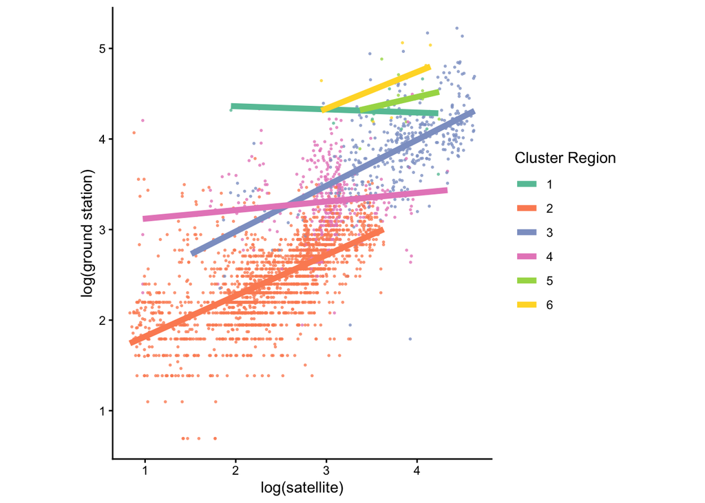

    ```r
    average <- GM@data |>
        group_by(iso3) |>
        summarise(pm25 = mean(pm25))

    clust <- dist(average$pm25) |>
        hclust() |>
        cutree(k = 6)

    GM@data$cluster_region <- as.character(clust[match(GM@data$iso3, average$iso3)])
    ggplot(GM@data, aes(log_sat, log_pm25)) +
        geom_point(aes(col = cluster_region), size = 0.4, alpha = 0.7) +
        geom_smooth(aes(col = cluster_region), method = "lm", se = FALSE, size = 2) +
        scale_color_brewer(palette = "Set2") +
        labs(x = "log(satellite)", y = "log(ground station)", col = "Cluster Region") +
        coord_fixed()
    ```

16. Which model should we actually use? In some of your other classes, you might have used cross-validation / test set error. While this is useful (and relatively automatic), it doesn’t necessarily tell you how to improve the model. An alternative which often brings more insight is to simulate from the model and see which aspects of the real data it can (and cannot) capture.

### Prior predictive distributions

17. The prior predictive distribution can be used to decide whether certain model families are reasonable candidates for a problem, before fitting the models to actual data. If the simulated datasets are plausible, then the overall model class is a reasonable one. If they are not, then the model class should be modified. Either the prior or the likelihood might need revision.
18. For example, in the example below, we simulate datasets two types of model assumptions, based on “vague” and “informative” priors, respectively. The first type of assumption is quite common in practice, and a version of this is likely what the 538 team used. However, in the PM2.5 example, the simulated data using the vague prior is not even remotely plausible.

    ```r
    # function to simulate from vague prior
    prior1 <- function(Nsim) {
        tau0 <- 1 / sqrt(rgamma(1, 1, rate = 100))
        tau1 <- 1 / sqrt(rgamma(1, 1, rate = 100))
        sigma <- 1 / sqrt(rgamma(1, 1, rate = 100))
        beta0i <- rnorm(7, 0, tau0)
        beta1i <- rnorm(7, 0, tau1)
        beta0 <- rnorm(1, 0, 100)
        beta1 <- rnorm(1, 0, 100)

        epsilon <- rnorm(Nsim, 0, sigma)
        data.frame(
            log_pm25 = GM$log_pm25,
            region = GM$super_region_name,
            sim = beta0 + beta0i[GM$super_region] + (beta1 + beta1i[GM$super_region]) * GM$log_sat + epsilon
        )
    }
    ```

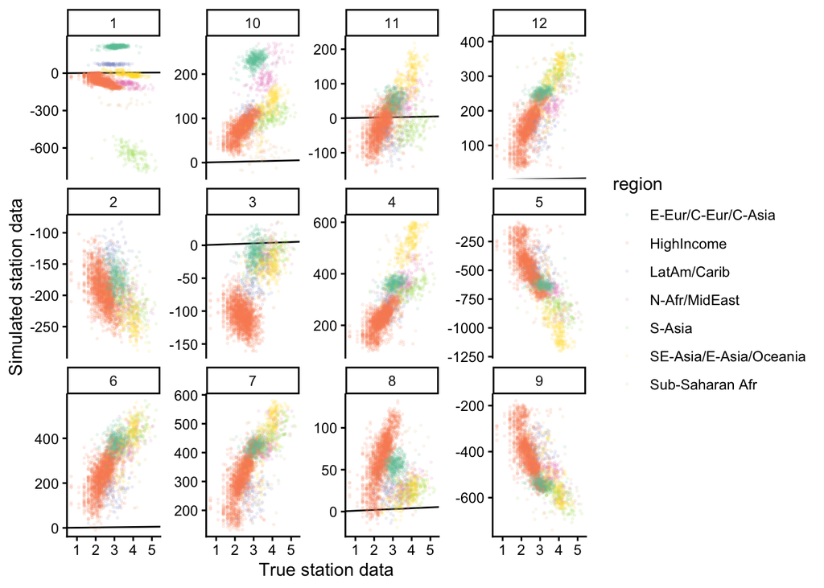

    Prior predictive samples from the vague prior are on a completely implausible scale.

    ```r
    prior1_data <- map_dfr(1:12, ~ prior1(Nsim = nrow(GM@data)), .id = "replicate")
    ggplot(prior1_data, aes(x = log_pm25, y = sim)) +
        geom_abline(slope = 1) +
        geom_point(aes(col = region), alpha = 0.1, size = 0.4) +
        scale_color_brewer(palette = "Set2") +
        labs(x = "True station data", y = "Simulated station data") +
        facet_wrap(~replicate, scale = "free_y")
    ```

19. The block below instead simulates from a subjective, informative prior. The resulting samples are much more plausible, lying in a comparable range to the true data. However, note that the samples from the prior predictive do not need to look exactly like the observed data. If they did, then we wouldn’t have to collect real data at all! All we ask is that they are roughly compatible with our prior knowledge of the problem setting.

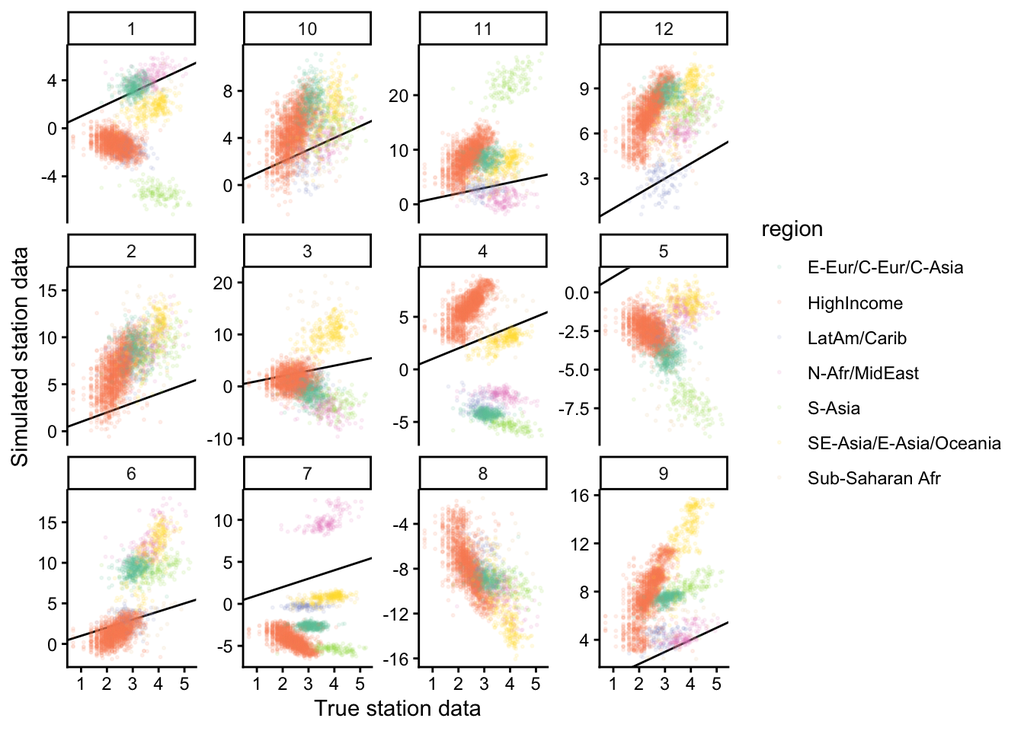

    Prior predictive samples from the weakly informative prior seem more plausible though they do not (and should not) exactly fit the true data.

    ```r
    # function to simulate from informative prior
    prior2 <- function(Nsim) {
        tau0 <- abs(rnorm(1, 0, 1))
        tau1 <- abs(rnorm(1, 0, 1))
        sigma <- abs(rnorm(1, 0, 1))
        beta0i <- rnorm(7, 0, tau0)
        beta1i <- rnorm(7, 0, tau1)
        beta0 <- rnorm(1, 0, 1)
        beta1 <- rnorm(1, 1, 1)

        epsilon <- rnorm(Nsim, 0, sigma)
        data.frame(
            log_pm25 = GM$log_pm25,
            region = GM$super_region_name,
            sim = beta0 + beta0i[GM$super_region] + (beta1 + beta1i[GM$super_region]) * GM$log_sat + epsilon
        )
    }

    prior2_data <- map_dfr(1:12, ~ prior2(Nsim = nrow(GM@data)), .id = "replicate")
    ggplot(prior2_data, aes(x = log_pm25, y = sim)) +
        geom_abline(slope = 1) +
        geom_point(aes(col = region), alpha = 0.1, size = 0.4) +
        scale_color_brewer(palette = "Set2") +
        labs(x = "True station data", y = "Simulated station data") +
        facet_wrap(~replicate, scale = "free_y")
    ```

### Posterior predictive distributions

    We use the `prior()` block at the top to specify a plausible values for each of the model parameters. For example, the first line encodes our assumption that the overall log(PM2.5) level should be centered around 0. This has the effect of stabilizing the model fit around this value.

    ```r
    dir.create("fits", showWarnings = FALSE)
    priors_lm <- c(
        prior(normal(0, 1), class = "b", coef = "Intercept"),
        prior(normal(1, 1), class = "b", coef = "log_sat"),
        prior(normal(0, 1), class = "sigma")
    )
    priors_hier <- c(priors_lm, prior(normal(0, 1), class = "sd"))

    models <- list(
        "lm" = brm(
            log_pm25 ~ 0 + Intercept + log_sat,
            data = GM@data, prior = priors_lm, chains = 1,
            file = "fits/pm25_lm"
        ),
        "regions" = brm(
            log_pm25 ~ 0 + Intercept + log_sat + (1 + log_sat || super_region_name),
            data = GM@data, prior = priors_hier, chains = 1,
            file = "fits/pm25_regions"
        ),
        "clusters" = brm(
            log_pm25 ~ 0 + Intercept + log_sat + (1 + log_sat || cluster_region),
            data = GM@data, prior = priors_hier, chains = 1,
            file = "fits/pm25_clusters"
        )
    )
    ```

22. The code above takes a bit of time, about 10 minutes. Afterwards, it gets saved to the `fits` directory. To simulate new PM2.5 data from the fitted models, we can call `posterior_predict()` on them. This is done in the block below simulates. Note that, compared to the prior predictive, the posterior predictive is much more closely related to the underlying dataset, which makes sense, because it has been trained to approximate it.

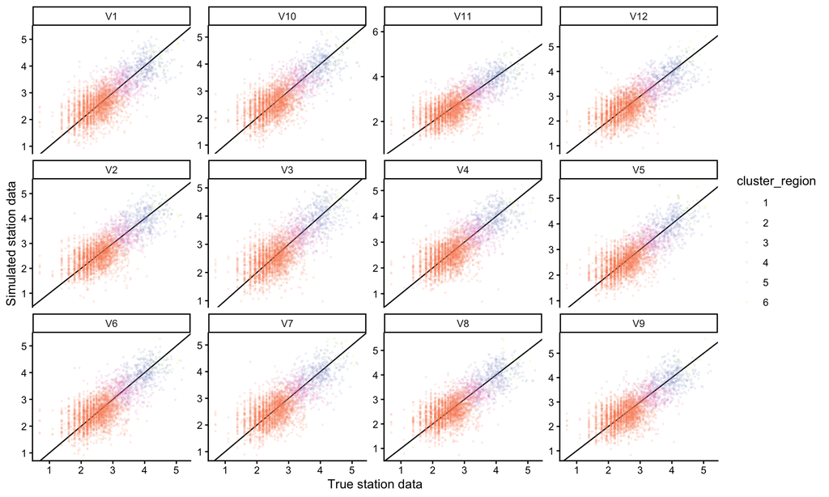

    Samples from the posterior predictive in the cluster-based model.

    ```r
    # extract 12 samples and reshape it to "long" format
    posterior_samples <- posterior_predict(models$clusters, ndraws = 12) |>
        t() |>
        as_tibble() |>
        bind_cols(GM@data) |>
        pivot_longer(V1:V12, names_to = "replicate", values_to = "log_pm25_sim")

    ggplot(posterior_samples, aes(log_pm25, log_pm25_sim)) +
        geom_abline(slope = 1) +
        geom_point(aes(col = cluster_region), size = 0.4, alpha = 0.1) +
        scale_color_brewer(palette = "Set2") +
        labs(x = "True station data", y = "Simulated station data") +
        facet_wrap(~replicate, scale = "free_y")
    ```

23. We can next define **test summaries** to see whether properties of the real data are captured by the posterior predictive distribution. In the block below, we compute the skewness for each simulated station dataset from the three different models. These skewnesses are plotted as histograms, with the true dataset’s skewness indicated by a vertical line. It seems that the model that uses clustering to define regions is able to simulate datasets with skewness similar to that in the real dataset.

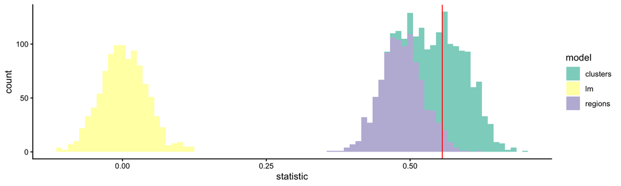

    Posterior simulated skewness according to the three different models.

    ```r
    apply_stat <- function(x, f) {
        z <- posterior_predict(x)
        tibble(
            "replicate" = seq_len(nrow(z)),
            "statistic" = apply(z, 1, f)
        )
    }

    skew <- function(x) {
        xdev <- x - mean(x)
        n <- length(x)
        r <- sum(xdev^3) / sum(xdev^2)^1.5
        r * sqrt(n) * (1 - 1 / n)^1.5
    }

    posteriors <- map_dfr(models, ~ apply_stat(., skew), .id = "model")
    truth <- skew(GM@data$log_pm25)
    ggplot(posteriors, aes(statistic)) +
        geom_histogram(aes(fill = model), binwidth = 0.01) +
        geom_vline(xintercept = truth, col = "red") +
        scale_fill_brewer(palette = "Set3")
    ```

    ```r
    x <- seq(-1, 1, length.out = 10)
    y <- 2 * x + 0.1 * rnorm(10)
    fit <- lm(y ~ x)
    simulate(fit, nsim = 8)
    ```

    ```
            sim_1       sim_2      sim_3      sim_4      sim_5      sim_6
    1  -1.9451903 -1.98975729 -2.0257283 -1.8773976 -1.9682019 -1.9779109
    2  -1.6379162 -1.57454425 -1.4806168 -1.4901730 -1.4974965 -1.5280357
    3  -1.2368340 -0.99437864 -1.0598506 -1.1698159 -1.2306425 -1.0777452
    4  -0.6983337 -0.80430678 -0.7248407 -0.8372840 -0.6681906 -0.5543370
    5  -0.2511139 -0.04256831 -0.4842365 -0.2448389 -0.3506367 -0.2219253
    6   0.2374614  0.20707081  0.1210030  0.2629631  0.2018739  0.2397630
    7   0.4759680  0.65914888  0.5665632  0.6716037  0.5937117  0.6323241
    8   1.1055168  0.93442278  1.0358997  0.9318135  1.1046414  0.9826161
    9   1.2480122  1.35902300  1.3253062  1.3868904  1.5290620  1.4144556
    10  1.8752603  1.84882786  1.9554769  1.8118326  1.9140802  1.9450419
            sim_7       sim_8
    1  -1.8660406 -2.01945836
    2  -1.5617944 -1.48851730
    3  -1.0871275 -1.27798872
    4  -0.7210214 -0.61045684
    5  -0.2554531 -0.28322675
    6   0.1756034  0.05474607
    7   0.6237121  0.59548957
    8   0.9170147  0.94340919
    9   1.5572177  1.50051699
    10  2.0222677  1.84280030
    ```

## Explaining Black Boxes

27. Specifically, we’ll focus on Partial dependence profiles (PDP) and individual conditional expectation (ICE) plots. They are general-purpose visualizations that attempt to explain how the model relates a predictor variable/set of predictor variables with the response.
28. Partial dependence profiles were first introduced as a minor point in an influential paper about gradient boosting (Friedman 2001). ICE and ALE were introduced to address some limitations of PDP, mainly related to the fact that prediction surfaces can become complicated in high-dimensions and when many interactions are present.
29. Let $f$ be the learned black box function. Let $x$ be its $D$-dimensional input. The idea is to ask how $f$ changes as we vary the $d$th coordinate over its range. We need to do something with the remaining coordinates. The idea of PDP is to average across them.

    $$\text{PDP}_d(z) = \mathbb{E}_{p(x_{-d})}\left[f(x_d = z, x_{-d})\right] \approx \frac{1}{N}\sum_{n=1}^N f(x_d = z, x_{n, -d})$$

    The highlighted part refers to manually intervening on the $d^{th}$ coordinate and setting it to $z$. If we evaluate this average across many different values of $z$, we get a PDP curve. Note that for each value $z$, we compute an average across the entire dataset, which can get slow.
30. Here is some geometric intuition. We take the original samples, manually set all their $d^{th}$ coordinates to $z$, evaluate the function $f$, and then average. We repeat this for many $z$’s to trace out the partial dependence curve.

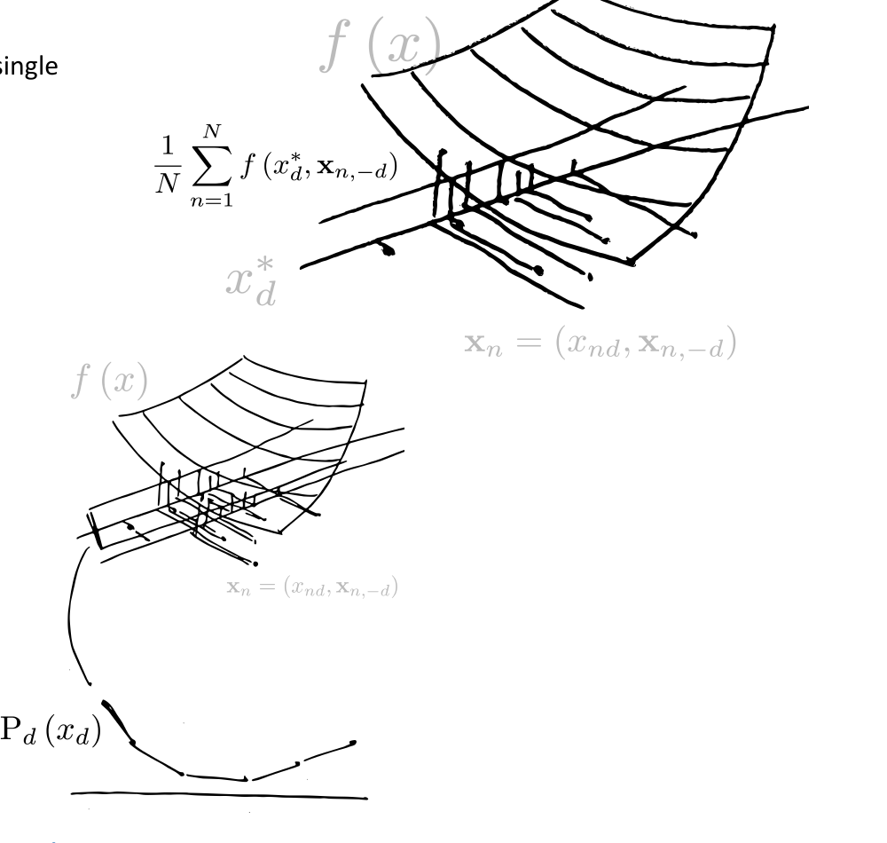

    Evaluating the PDP at a single value $z = x_d^*$ (top) and repeating this across many $z$ to trace out the $\text{PDP}_d(x_d)$ curve (bottom).

## Individual Conditional Expectations

31. ICE plots consider each term in the PDP formula as its own function of $z$.

    $$h_n(z) := f(x_d = z, x_{n, -d})$$

    This has the nice “Ceteris Paribus” interpretation. For each sample, it traces out the curve where the $d$th coordinate is set to different values $z$ but all other coordinates are held fixed.
32. The key insight is that these curves can be meaningful on their own. The averaging step in PDP can mask some meaningful variation in model predictions. This is especially useful for discovering interactions. For example, here are ICE curves for a model trained to predict survival with the Titanic dataset. The age effect is very different for crew vs. passengers.

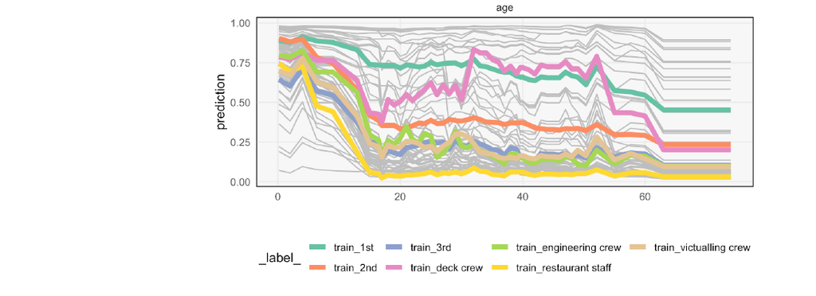

    ICE (“Ceteris Paribus”) curves for a survival model fit to the Titanic dataset, colored by passenger/crew class.

33. Two common tricks for ICE plots:
    - We might suspect an interaction with an unmeasured variable. This can sometimes be seen as groups of curves with different shapes, but where we don’t have a variable in the data that splits those groups. In this case, people often cluster the curves and use cluster membership as a stand in for the unobserved interacting variable.

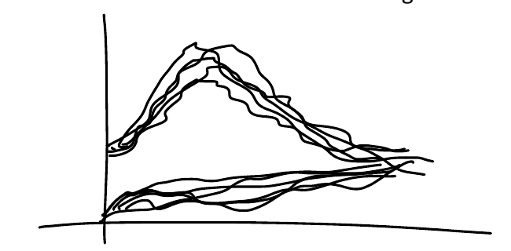

    Groups of ICE curves with different shapes can suggest an interaction with an unmeasured variable; clustering the curves gives a stand-in for that variable.

    - Often the curves are offset because of differences in the coordinates other than the $d$th. To see whether they nonetheless have similar shapes, it’s sometimes helpful to “center” the curves, so that they all start out equal to one another.

    $$\tilde{h}_n(z) = f(x_d = z, x_{n, -d}) - f(x_d = 0, x_{n, -d})$$

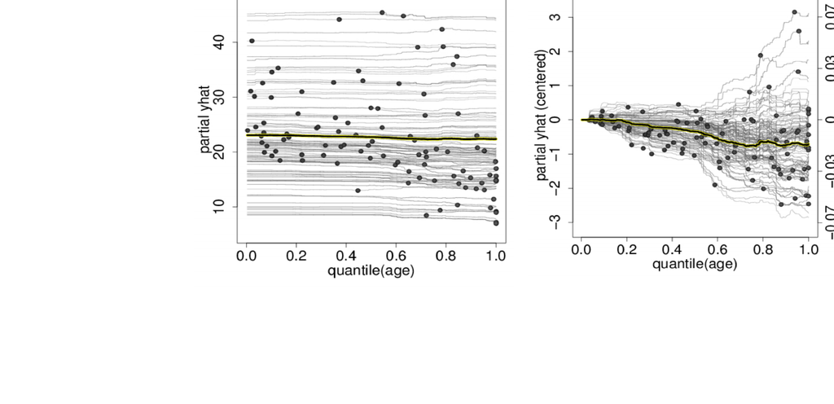

    Raw ICE curves for a partial $\hat{y}$ vs. age relationship (left) and the same curves after centering (right); centering makes it easier to compare shapes across curves that start at different levels.

34. Partial dependence (PD) plots help answer the question, « How is feature $j$ used by my model $f$? » Slight variations on PD plots are useful for some related followup questions,
    - Has my model $f$ learned interactions between features $j$ and $j^{\prime}$?
    - How do the models $f$ and $f^{\prime}$ differ in the way that they use feature $j$?
35. The variants, called Grouped and Contrastive PD plots, reduce the original CP profiles less aggressively than PD plots, but without becoming overwhelmingly complicated.

### Interactions

    ```r
    f <- tempfile()
    download.file("https://uwmadison.box.com/shared/static/nau695mppsoxx0f6bns1ieo7kh1bje0j.rda", f)
    fit <- get(load(f))

    data(titanic)
    titanic <- titanic |>
        select(-country) |>
        na.omit()
    x <- select(titanic, -survived)

    explanation <- explain(model = fit, data = x, y = titanic$survived)
    ```

    ```
      -> residuals         :  numerical, min =  NA , mean =  NA , max =  NA
      A new explainer has been created!
    ```

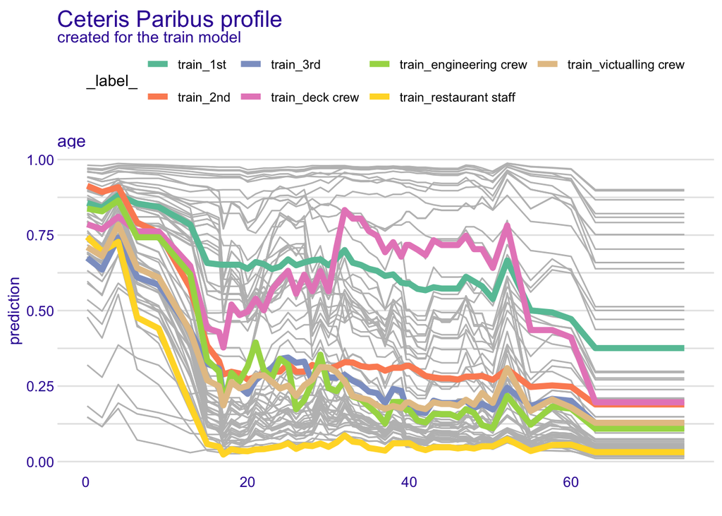

    Grouping the CP profiles by ticket class reveals an interaction effect with age in the Titanic dataset.

    ```r
    profiles <- model_profile(explainer = explanation, groups = "class")
    plot(profiles, geom = "profiles", variables = "age") +
        scale_color_brewer(palette = "Set2")
    ```

39. What should we do if there are many input variables and we don’t have a priori knowledge about which variables $j^{\prime}$ might be interacting with $j$? One idea is to try to *discover* relevant interactions by clustering the original set of CP profiles.
40. In more detail, we can compute the CP profiles for all the samples, and then see whether there are subsets of profiles that all look similar. If we find features $j^{\prime}$ that characterize these groupings, then we have found features that interact with $j$ (with respect to the fitted model $f$). The plot below shows the same profiles as above, but clustering directly. It seems to recover the interaction between age and class, even though we have not explicitly provided this grouping variable.

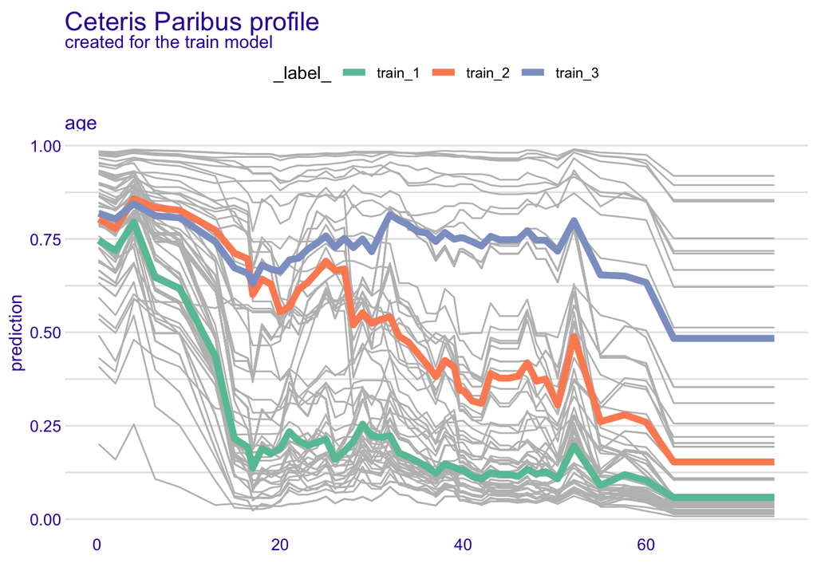

    Discovered groupings in the CP profiles for age reveals an interaction effect.

    ```r
    profiles <- model_profile(explainer = explanation, variables = "age", k = 3)
    plot(profiles, geom = "profiles", variables = "age") +
        scale_color_brewer(palette = "Set2")
    ```

### Model Comparison

41. The comparison of different models’ PD profiles can be used to,
    - Validate a simple model
    - Guide the design of new features, and
    - Characterizing overfitting PD profiles that are used to compare different models are sometimes called « Contrastive » PD profiles.
42. To validate a simple model, we can compare its PD profiles with those of a more sophisticated model. We will illustrate this by fitting linear and random forest models to a dataset of apartment prices[^2]. Given various properties of an apartment, the goal is to determine its price. The code below fits the two models and extracts their CP and PD profiles.

    ```r
    data(apartments)
    x <- select(apartments, -m2.price)
    profiles_lm <- train(x, apartments$m2.price, method = "lm") |>
        explain(x, apartments$m2.price, label = "LM") |>
        model_profile()
    ```

    ```r
    profiles_rf <- train(x, apartments$m2.price, method = "rf", tuneGrid = data.frame(mtry = 10)) |>
        explain(x, apartments$m2.price, label = "RF") |>
        model_profile()
    ```

43. The PD profile below shows that the random forest learns linear relationships with price for both the surface and floor variables. If all the effects were like this, then we would have a good reason for preferring the linear model.

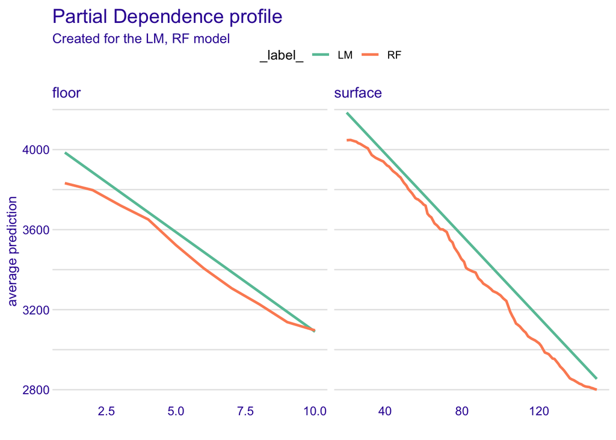

    A contrastive PD display suggests that the floor and surface features are linearly related with apartment price.

    ```r
    plot(profiles_lm, profiles_rf, variables = c("surface", "floor")) +
        scale_color_brewer(palette = "Set2")
    ```

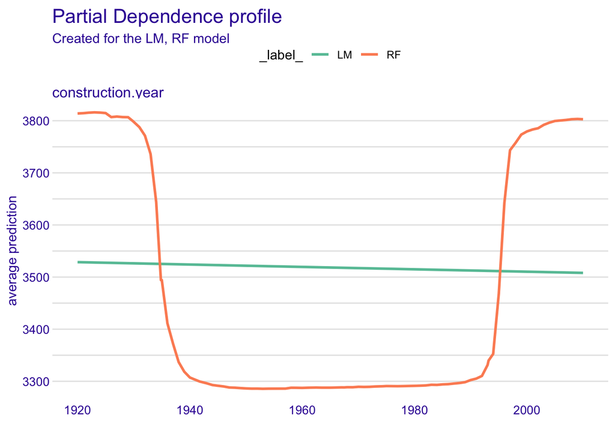

    The random forest learns a nonlinear relationship between construction year and apartment price. This suggests designing new features to include in the linear model.

    ```r
    plot(profiles_lm, profiles_rf, variables = "construction.year") +
        scale_color_brewer(palette = "Set2")
    ```

45. Suppose you have found that a model is overfitting (e.g., by finding that it’s training error is much lower than its test error). One way to address this overfitting is to compare the PD profiles between the simple and complex models. If the profiles are very different for one of the features, then that feature may be the source of overfitting.

## References

Friedman, Jerome H. 2001. “Greedy Function Approximation: A Gradient Boosting Machine.” *Annals of Statistics*, 1189–232.

## Footnotes

[^1]: In any HW or exam questions, we will give you `brms` code. You don’t need to know how to run the models, just how to visualize the simulated samples.
[^2]: It is a simulated dataset, but designed to reflect properties of a real dataset.